# Comic Characters 538

2019/04/12

## สมาชิกกลุ่ม

### สมาชิกคนที่ 1

ชื่อ: นายวิพุธ ภู่ทอง

รหัสนักศึกษา: 60070090

เวลาเรียน: อังคาร 13:30 - 16:30 น.

### สมาชิกคนที่ 2

ชื่อ: นายธีรภัทร ไกรศรีสิริกุล

รหัสนักศึกษา: 60070183

เวลาเรียน: อังคาร 13:30 - 16:30 น.

## โจทย์ปัญหา

1. Marvel หรือ DC เขียนตัวละครมาแล้วเสียชีวิตไปมากกว่ากัน?
2. เพศและฝั่งของตัวละครมีผลหรือแนวโน้มที่จะถูกเขียนให้เสียชีวิตมากน้อยเท่าไร?

ชุดข้อมูลที่ใช้จาก fivethirtyeight : comic_characters

## ขั้นตอนการดำเนินการ

### 1.) โหลด Library

```r
library(tidyverse)
library(fivethirtyeight)
library(stringr)
library(ggthemes)
```

### 2.) ทดลองดูข้อมูล

```r
comic_characters
```

```
## # A tibble: 23,272 x 16
##    publisher page_id name  urlslug id    align eye   hair  sex   gsm
##    <chr>       <int> <chr> <chr>   <chr> <ord> <chr> <chr> <chr> <chr>
##  1 Marvel       1678 Spid… "\\/Sp… Secr… Good… Haze… Brow… Male… <NA>
##  2 Marvel       7139 Capt… "\\/Ca… Publ… Good… Blue… Whit… Male… <NA>
##  3 Marvel      64786 "Wol… "\\/Wo… Publ… <NA>  Blue… Blac… Male… <NA>
##  4 Marvel       1868 "Iro… "\\/Ir… Publ… Good… Blue… Blac… Male… <NA>
##  5 Marvel       2460 Thor… "\\/Th… No D… Good… Blue… Blon… Male… <NA>
##  6 Marvel       2458 Benj… "\\/Be… Publ… Good… Blue… No H… Male… <NA>
##  7 Marvel       2166 Reed… "\\/Re… Publ… Good… Brow… Brow… Male… <NA>
##  8 Marvel       1833 Hulk… "\\/Hu… Publ… Good… Brow… Brow… Male… <NA>
##  9 Marvel      29481 Scot… "\\/Sc… Publ… <NA>  Brow… Brow… Male… <NA>
## 10 Marvel       1837 Jona… "\\/Jo… Publ… Good… Blue… Blon… Male… <NA>
## # … with 23,262 more rows, and 6 more variables: alive <chr>,
## #   appearances <int>, first_appearance <chr>, month <chr>, year <int>,
## #   date <date>
```

### 3.) หาคำตอบ

#### 3.1.) ดูว่าตัวละครจากค่ายหนังสือการ์ตูนทั้ง Marvel และ DC นั้นมีอัตราการเสียชีวิตเท่าไร

```r
by_publisher <- comic_characters %>%
                count(publisher, alive) %>%
                filter(!is.na(alive))

by_publisher
```

```
## # A tibble: 4 x 3
##   publisher alive                   n
##   <chr>     <chr>               <int>
## 1 DC        Deceased Characters  1693
## 2 DC        Living Characters    5200
## 3 Marvel    Deceased Characters  3765
## 4 Marvel    Living Characters   12608
```

#### 3.2.) ดูปัจจัยอื่นอย่างเพศและฝั่งของตัวละคร ว่ามีอัตราการเสียชีวิตเท่าไร

```r
by_sex <- comic_characters %>%
          count(sex, alive) %>%
          filter(!is.na(alive)) %>%
          filter((sex == 'Male Characters') | (sex == 'Female Characters'))

by_sex
```

```
## # A tibble: 4 x 3
##   sex               alive                   n
##   <chr>             <chr>               <int>
## 1 Female Characters Deceased Characters  1155
## 2 Female Characters Living Characters    4648
## 3 Male Characters   Deceased Characters  4140
## 4 Male Characters   Living Characters   12280
```

```r
by_align <- comic_characters %>%
            count(align, alive) %>%
            filter(!is.na(alive)) %>%
            filter(align == 'Bad Characters' | align == 'Good Characters' | is.na(align))
by_align
```

```
## # A tibble: 6 x 3
##   align           alive                   n
##   <ord>           <chr>               <int>
## 1 Bad Characters  Deceased Characters  2732
## 2 Bad Characters  Living Characters    6882
## 3 Good Characters Deceased Characters  1513
## 4 Good Characters Living Characters    5954
## 5 <NA>            Deceased Characters  1212
## 6 <NA>            Living Characters    4970
```

### 4.) นำข้อมูลมานำเสนอ (Data Visualization)

#### 4.1.) ใช้ Bar Chart

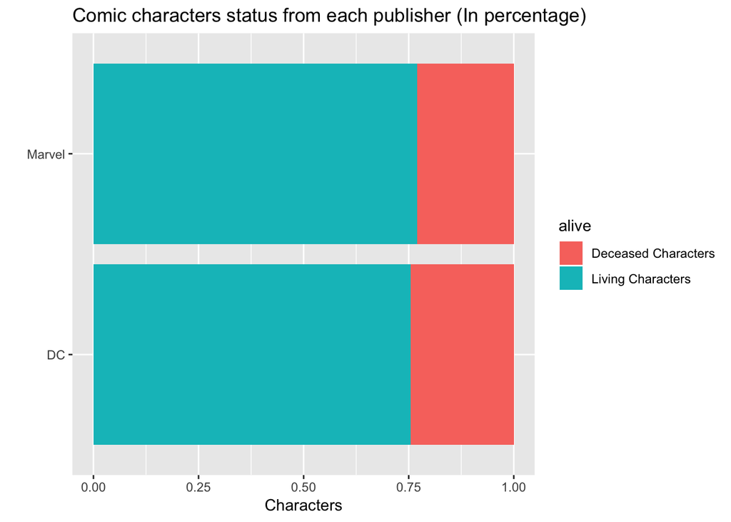

```r
p1 <- ggplot(data=by_publisher, aes(x = publisher, y = n)) +
      # map "alive" of beverage to aes "fill"" of the bar
      geom_col(aes(fill = alive), position = position_fill()) +
      # flip coordinate
      coord_flip() +
      # add labels
      labs(x="", y="Characters", title="Comic characters status from each publisher (In percentage)")

p1
```

#### 4.2.) ใช้ Bar Chart

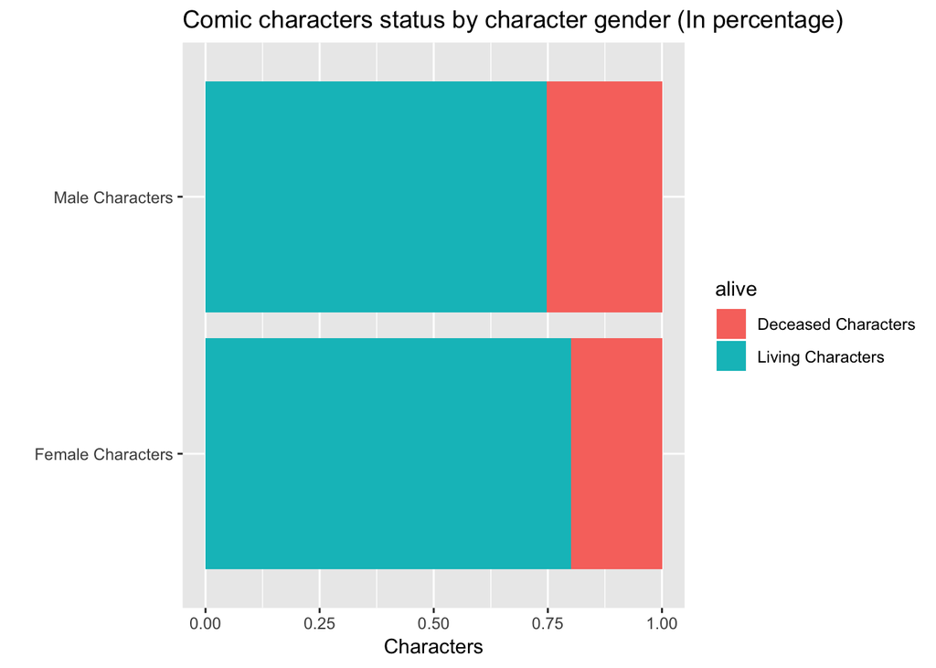

```r
p2 <- ggplot(data=by_sex, aes(x = sex, y = n)) +
      # map "alive" of beverage to aes "fill"" of the bar
      geom_col(aes(fill = alive), position = position_fill()) +
      # flip coordinate
      coord_flip() +
      # add labels
      labs(x="", y="Characters", title="Comic characters status by character gender (In percentage)")

p2
```

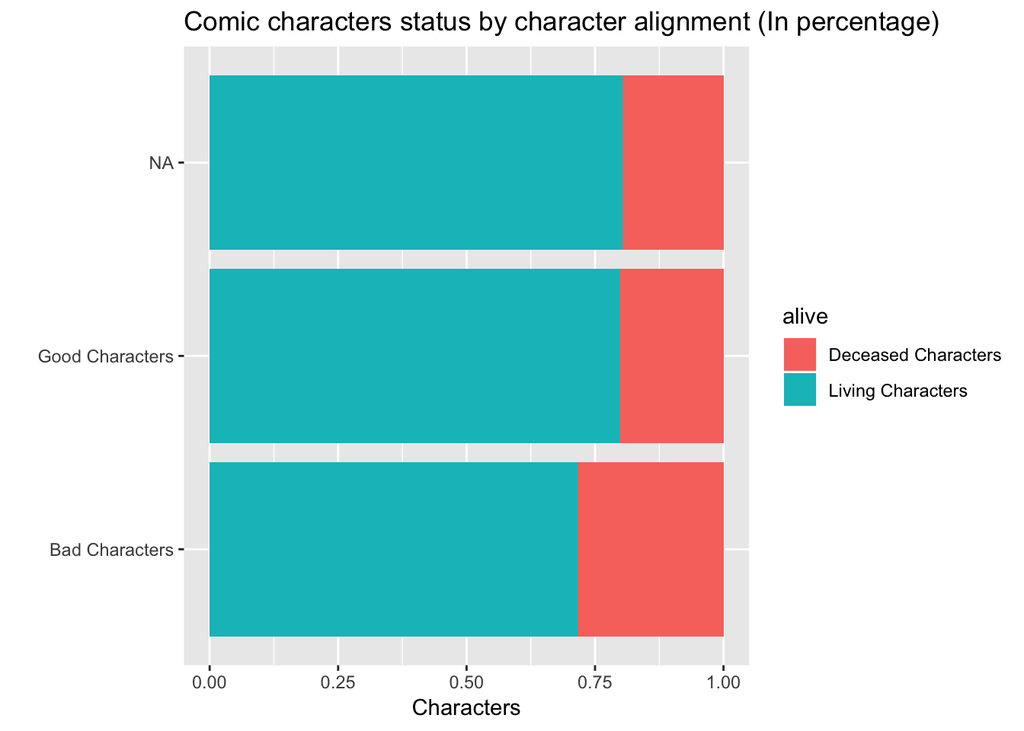

```r
p3 <- ggplot(data=by_align, aes(x = align, y = n)) +
      # map "alive" of beverage to aes "fill"" of the bar
      geom_col(aes(fill = alive), position = position_fill()) +
      # flip coordinate
      coord_flip() +
      # add labels
      labs(x="", y="Characters", title="Comic characters status by character alignment (In percentage)")

p3
```

## สรุปผล

### 1.)

จะสังเกตได้ว่า ทั้ง Marvel และ DC นั้นมีการเขียนให้ตัวละครเสียชีวิตในอัตราที่ใกล้เคียงกัน โดยอัตราการเสียชีวิตของตัวละครจาก Marvel อยู่ที่ 23.0% และตัวละครจาก DC อยู่ที่ 24.56%

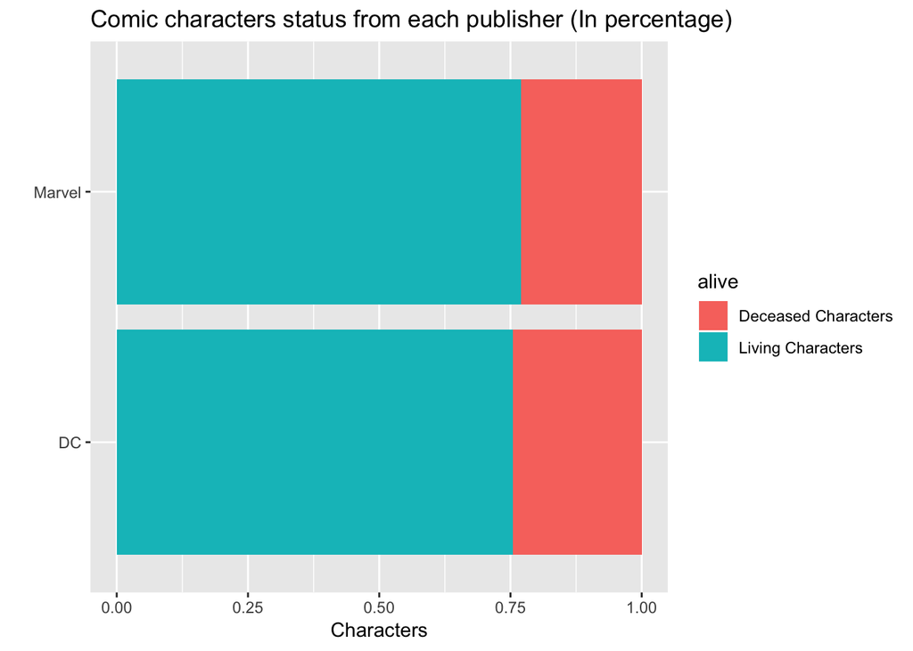

```r
p1
```

### 2.)

ต่อมาหากดูจากเพศของตัวละคร จะสังเกตได้ว่า อัตราการเสียชีวิตของตัวละครเพศชาย มีมากกว่าตัวละครเพศหญิงเล็กน้อย โดยตัวละครเพศหญิงมีอัตราการเสียชีวิตอยู่ที่ 19.9% และตัวละครเพศชายมีอัตราการเสียชีวิตที่ 25.21%

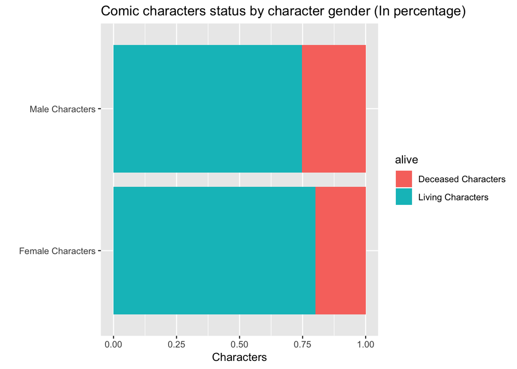

```r
p2
```

สุดท้ายหากดูจากฝ่ายของตัวละครก็จะพบว่า ตัวละครที่ไม่อยู่ฝั่งใดฝ่ายหนึ่งหรือฝ่ายดี มีอัตราการเสียชีวิตน้อยกว่าตัวละครฝ่ายร้ายระดับหนึ่ง โดยตัวละครที่ไม่อยู่ฝ่ายใดฝ่ายหนึ่งมีอัตราการเสียชีวิตอยู่ที่ 19.61% ตัวละครฝ่ายดีอยู่ที่ 20.26% และตัวละครฝ่ายร้ายอยู่ที่ 28.42%

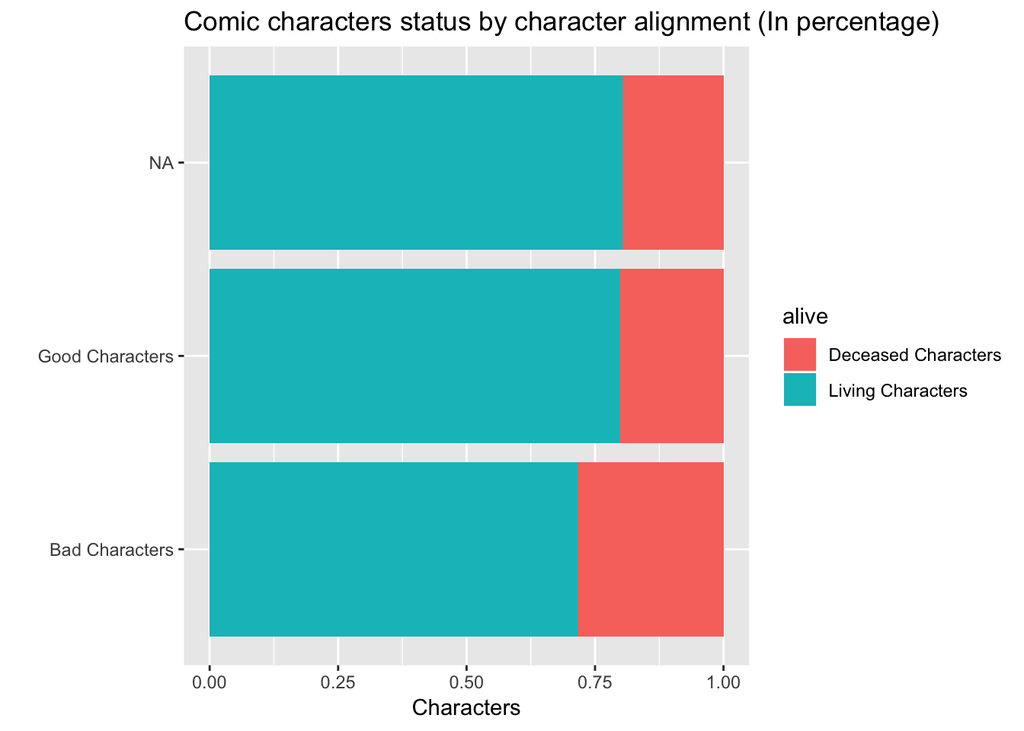

```r
p3
```